# Case Study: Boston Housing Dataset

Emma Bennett, Pallavi, Lily

UC3M, 2025

```r
# Importing libraries
library(mlbench)
library(tidyverse)
```

```r
library(tibble)
library(knitr)
library(ggcorrplot)
library(mapview)
library(sf)
library(GGally)
library(factoextra)
```

## Information about dataset

According to the description it consists of housing data for 506 census tracts of Boston from the 1970 census.

This dataset that we chose is good for a lot of these dimensionality reduction techniques (like factor analysis and PCA) because it has a good number of quantitative variables and is well-structured and easy to visualize.

The following are the columns of the dataset:

- **CRIM** — per capita crime rate by town
- **ZN** — proportion of residential land zoned for lots over 25,000 sq.ft.
- **INDUS** — proportion of non-retail business acres per town
- **CHAS** — Charles River dummy variable (1 if tract bounds river; 0 otherwise)
- **NOX** — nitric oxides concentration (parts per 10 million)
- **RM** — average number of rooms per dwelling
- **AGE** — proportion of owner-occupied units built prior to 1940
- **DIS** — weighted distances to five Boston employment centres
- **RAD** — index of accessibility to radial highways
- **TAX** — full-value property-tax rate per $10,000
- **PTRATIO** — pupil-teacher ratio by town
- **B** — 1000(Bk − 0.63)² where Bk is the proportion of blacks by town
- **LSTAT** — % lower status of the population
- **MEDV** — median value of owner-occupied homes in $1000’s
- **TOWN** — name of the town
- **TRACT** — census tract number within the town
- **LON** — longitude coordinate of the census tract centroid
- **LAT** — latitude coordinate of the census tract centroid
- **CMEDV** — corrected median value of owner-occupied homes (in $1000’s, accounting for inflation and updates)

## Loading data

```r
data("BostonHousing", package = "mlbench")
data("BostonHousing2", package = "mlbench")
summary(BostonHousing2)
```

```
##                 town         tract           lon              lat
##  Cambridge        : 30   Min.   :   1   Min.   :-71.29   Min.   :42.03
##  Boston Savin Hill: 23   1st Qu.:1303   1st Qu.:-71.09   1st Qu.:42.18
##  Lynn             : 22   Median :3394   Median :-71.05   Median :42.22
##  Boston Roxbury   : 19   Mean   :2700   Mean   :-71.06   Mean   :42.22
##  Newton           : 18   3rd Qu.:3740   3rd Qu.:-71.02   3rd Qu.:42.25
##  Somerville       : 15   Max.   :5082   Max.   :-70.81   Max.   :42.38
##  (Other)          :379
##       medv           cmedv            crim                zn
##  Min.   : 5.00   Min.   : 5.00   Min.   : 0.00632   Min.   :  0.00
##  1st Qu.:17.02   1st Qu.:17.02   1st Qu.: 0.08205   1st Qu.:  0.00
##  Median :21.20   Median :21.20   Median : 0.25651   Median :  0.00
##  Mean   :22.53   Mean   :22.53   Mean   : 3.61352   Mean   : 11.36
##  3rd Qu.:25.00   3rd Qu.:25.00   3rd Qu.: 3.67708   3rd Qu.: 12.50
##  Max.   :50.00   Max.   :50.00   Max.   :88.97620   Max.   :100.00
##
##      indus       chas         nox               rm             age
##  Min.   : 0.46   0:471   Min.   :0.3850   Min.   :3.561   Min.   :  2.90
##  1st Qu.: 5.19   1: 35   1st Qu.:0.4490   1st Qu.:5.886   1st Qu.: 45.02
##  Median : 9.69           Median :0.5380   Median :6.208   Median : 77.50
##  Mean   :11.14           Mean   :0.5547   Mean   :6.285   Mean   : 68.57
##  3rd Qu.:18.10           3rd Qu.:0.6240   3rd Qu.:6.623   3rd Qu.: 94.08
##  Max.   :27.74           Max.   :0.8710   Max.   :8.780   Max.   :100.00
##
##       dis              rad              tax           ptratio
##  Min.   : 1.130   Min.   : 1.000   Min.   :187.0   Min.   :12.60
##  1st Qu.: 2.100   1st Qu.: 4.000   1st Qu.:279.0   1st Qu.:17.40
##  Median : 3.207   Median : 5.000   Median :330.0   Median :19.05
##  Mean   : 3.795   Mean   : 9.549   Mean   :408.2   Mean   :18.46
##  3rd Qu.: 5.188   3rd Qu.:24.000   3rd Qu.:666.0   3rd Qu.:20.20
##  Max.   :12.127   Max.   :24.000   Max.   :711.0   Max.   :22.00
##
##        b              lstat
##  Min.   :  0.32   Min.   : 1.73
##  1st Qu.:375.38   1st Qu.: 6.95
##  Median :391.44   Median :11.36
##  Mean   :356.67   Mean   :12.65
##  3rd Qu.:396.23   3rd Qu.:16.95
##  Max.   :396.90   Max.   :37.97
##
```

```r
glimpse(BostonHousing2)
```

```
## Rows: 506
## Columns: 19
## $ town    <fct> Nahant, Swampscott, Swampscott, Marblehead, Marblehead, Marble…
## $ tract   <int> 2011, 2021, 2022, 2031, 2032, 2033, 2041, 2042, 2043, 2044, 20…
## $ lon     <dbl> -70.9550, -70.9500, -70.9360, -70.9280, -70.9220, -70.9165, -7…
## $ lat     <dbl> 42.2550, 42.2875, 42.2830, 42.2930, 42.2980, 42.3040, 42.2970,…
## $ medv    <dbl> 24.0, 21.6, 34.7, 33.4, 36.2, 28.7, 22.9, 27.1, 16.5, 18.9, 15…
## $ cmedv   <dbl> 24.0, 21.6, 34.7, 33.4, 36.2, 28.7, 22.9, 22.1, 16.5, 18.9, 15…
## $ crim    <dbl> 0.00632, 0.02731, 0.02729, 0.03237, 0.06905, 0.02985, 0.08829,…
## $ zn      <dbl> 18.0, 0.0, 0.0, 0.0, 0.0, 0.0, 12.5, 12.5, 12.5, 12.5, 12.5, 1…
## $ indus   <dbl> 2.31, 7.07, 7.07, 2.18, 2.18, 2.18, 7.87, 7.87, 7.87, 7.87, 7.…
## $ chas    <fct> 0, 0, 0, 0, 0, 0, 0, 0, 0, 0, 0, 0, 0, 0, 0, 0, 0, 0, 0, 0, 0,…
## $ nox     <dbl> 0.538, 0.469, 0.469, 0.458, 0.458, 0.458, 0.524, 0.524, 0.524,…
## $ rm      <dbl> 6.575, 6.421, 7.185, 6.998, 7.147, 6.430, 6.012, 6.172, 5.631,…
## $ age     <dbl> 65.2, 78.9, 61.1, 45.8, 54.2, 58.7, 66.6, 96.1, 100.0, 85.9, 9…
## $ dis     <dbl> 4.0900, 4.9671, 4.9671, 6.0622, 6.0622, 6.0622, 5.5605, 5.9505…
## $ rad     <int> 1, 2, 2, 3, 3, 3, 5, 5, 5, 5, 5, 5, 5, 4, 4, 4, 4, 4, 4, 4, 4,…
## $ tax     <int> 296, 242, 242, 222, 222, 222, 311, 311, 311, 311, 311, 311, 31…
## $ ptratio <dbl> 15.3, 17.8, 17.8, 18.7, 18.7, 18.7, 15.2, 15.2, 15.2, 15.2, 15…
## $ b       <dbl> 396.90, 396.90, 392.83, 394.63, 396.90, 394.12, 395.60, 396.90…
## $ lstat   <dbl> 4.98, 9.14, 4.03, 2.94, 5.33, 5.21, 12.43, 19.15, 29.93, 17.10…
```

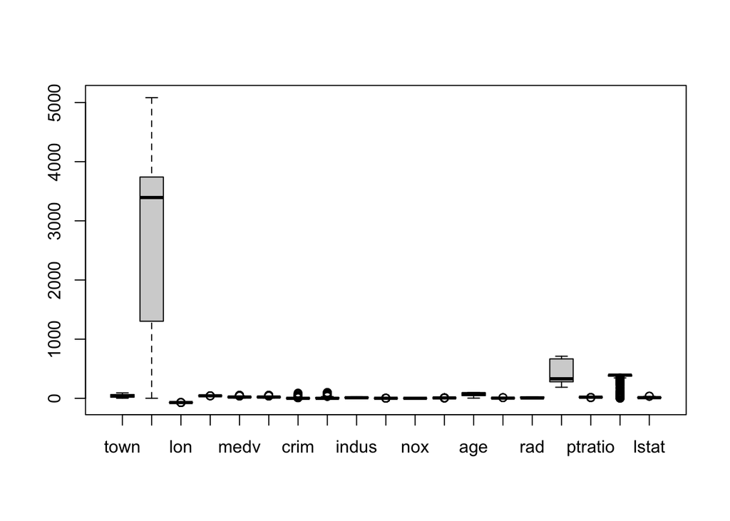

```r
boxplot(BostonHousing2)
```

### Overlaying Map to Boston Housing

```python
# import numpy as np
# import pandas as pd
#
# # Assuming df = BostonHousing2 loaded as pandas DataFrame
# # and town_names, lat_long = reference coordinates of town centers
#
# lat_long_values = []
#
# # Calculate the per-town mean lat/lon
# wrong_values = df.groupby('TOWN')[['LAT', 'LON']].mean()
#
# # Iterate through each town and its reference point
# for name, (lat, lon) in zip(town_names, lat_long):
#     df_temp = df[df.TOWN == name]
#     mean_temp = wrong_values.loc[name].values  # [mean_lat, mean_lon]
#
#     for lat_local, lon_local in df_temp[['LAT', 'LON']].values:
#         # difference from mean position
#         diff_lat = lat_local - mean_temp[0]
#         diff_lon = lon_local - mean_temp[1]
#
#         # translated position relative to reference point
#         lat_long_values.append([lat + diff_lat, lon + diff_lon])
#
# # Replace in dataframe
# df = df.sort_values('TOWN').copy()
# df[['LAT', 'LON']] = np.asarray(lat_long_values)
#
# # Rename to lowercase for mapview compatibility
# df.rename(columns={'LAT': 'lat', 'LON': 'lon'}, inplace=True)
#
# # Export to R if needed:
# df.to_csv("BostonHousing2_corrected.csv", index=False)
```

```r
library(mapview)
#BostonHousing2 <- read.csv("BostonHousing2_corrected.csv")

#mapview(BostonHousing2, xcol = "lon", ycol = "lat", grid = TRUE, crs = 4326)
```

## Data preprocessing

Below we are going to do some preprocessing on the data including dealing with outliers, checking if there are any NA values, and other feature engineering.

### Outliers

Here, we are identifying outliers (extreme values) in the Boston Housing dataset.

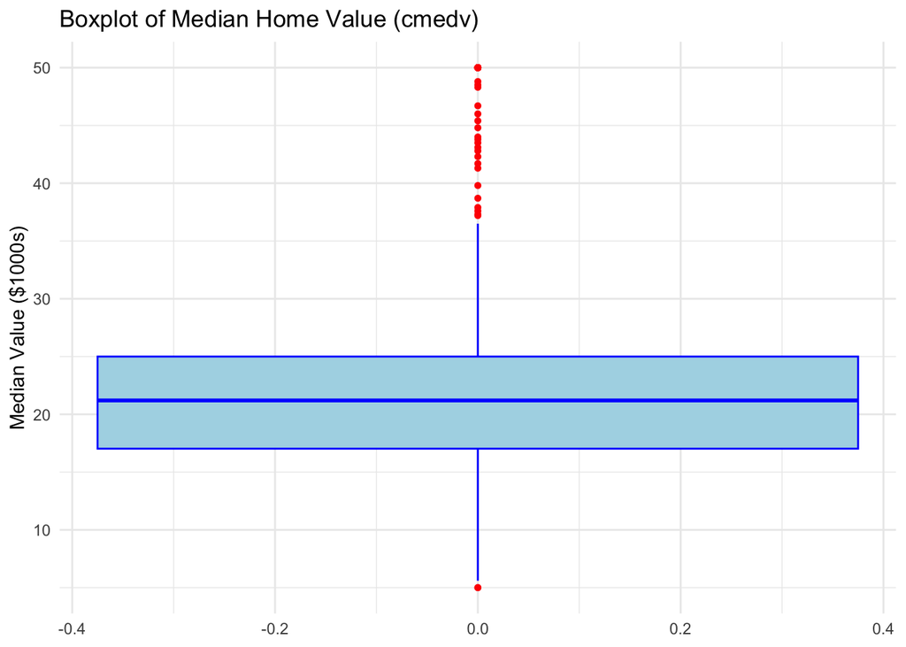

```r
# Example: Corrected median value of owner-occupied homes (cmedv)
BostonHousing2 %>%
  ggplot(aes(y = cmedv)) +
  geom_boxplot(fill = "lightblue", color = "blue",
               outlier.color = "red", outlier.shape = 16) +
  theme_minimal() +
  labs(title = "Boxplot of Median Home Value (cmedv)",
       y = "Median Value ($1000s)")
```

```r
# Identification by the 3-sigma rule
mu <- mean(BostonHousing2$cmedv, na.rm = TRUE)
sigma <- sd(BostonHousing2$cmedv, na.rm = TRUE)

sum(BostonHousing2$cmedv < mu - 3*sigma | BostonHousing2$cmedv > mu + 3*sigma)
```

```
## [1] 0
```

```r
# Identification by the IQR method
QI <- quantile(BostonHousing2$cmedv, 0.25, na.rm = TRUE)
QS <- quantile(BostonHousing2$cmedv, 0.75, na.rm = TRUE)
IQR <- QS - QI

sum(BostonHousing2$cmedv < QI - 1.5*IQR | BostonHousing2$cmedv > QS + 1.5*IQR)
```

```
## [1] 39
```

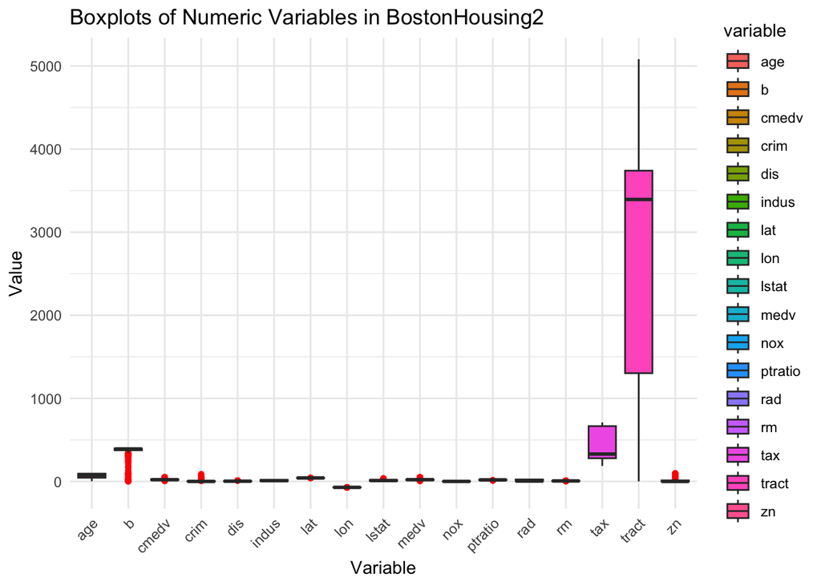

```r
# Depending on the context, we must decide what to do:
# - Remove them if they are errors or impossible values
# - Keep them if they represent true extreme cases

# Extend analysis to all numeric variables
numeric_vars <- BostonHousing2 %>% select(where(is.numeric))

numeric_vars %>%
  pivot_longer(cols = everything(), names_to = "variable", values_to = "value") %>%
  ggplot(aes(x = variable, y = value, fill = variable)) +
  geom_boxplot(outlier.color = "red", outlier.shape = 16) +
  theme_minimal() +
  theme(axis.text.x = element_text(angle = 45, hjust = 1)) +
  labs(title = "Boxplots of Numeric Variables in BostonHousing2",
       x = "Variable",
       y = "Value")
```

### NA/Missing Values

In this dataset there are no missing values.

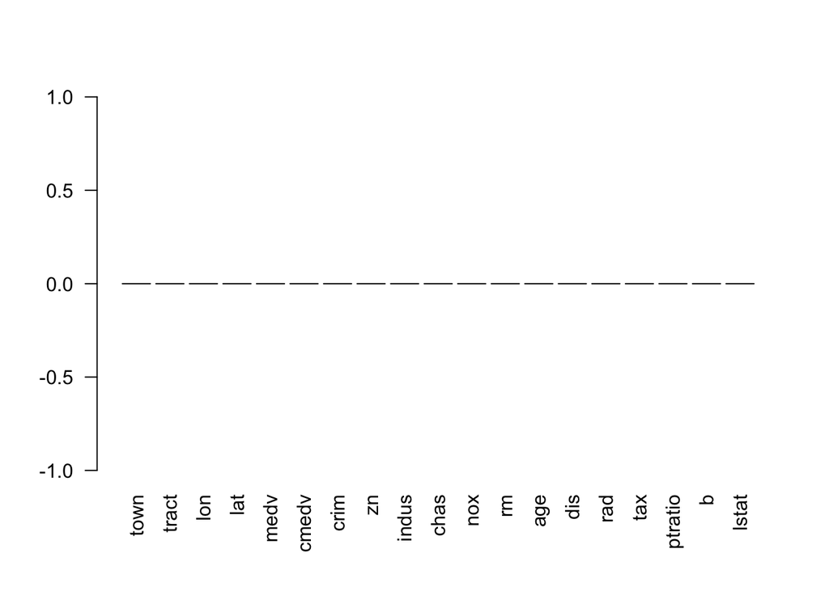

```r
barplot(colMeans(is.na(BostonHousing2)), las=2)
```

## Regression models and resampling tools

Come up with a variable that you want to predict - we want to predict cmev

```r
set.seed(123)

n_sims = 1000        # number of simulation runs
n_models = 4         # number of models
n = nrow(BostonHousing2)
n_train = round(0.8 * n)

# Create a matrix to store predictions
predictions = matrix(0, nrow = n_sims, ncol = n_models)

# Choose a fixed x0 point to predict (optional)
x0 = data.frame(rm = 6, ptratio = 15, lstat = 10)

# Simulation loop
for (i in 1:n_sims) {
  # Split data into train/test
  ind.train = sample(1:n, n_train, replace = FALSE)
  train = BostonHousing2[ind.train, ]
  test  = BostonHousing2[-ind.train, ]

  # Fit four models
  fit_1 = lm(cmedv ~ rm, data = train)
  fit_2 = lm(cmedv ~ ptratio, data = train)
  fit_3 = lm(cmedv ~ lstat, data = train)
  fit_4 = lm(cmedv ~ rm + ptratio + lstat, data = train)

  pred1 = predict(fit_1, newdata = test)
  pred2 = predict(fit_2, newdata = test)
  pred3 = predict(fit_3, newdata = test)
  pred4 = predict(fit_4, newdata = test)

  mse1 = mean((pred1 - test$cmedv)^2)
  mse2 = mean((pred2 - test$cmedv)^2)
  mse3 = mean((pred3 - test$cmedv)^2)
  mse4 = mean((pred4 - test$cmedv)^2)

  predictions[i, ] = c(mse1, mse2, mse3, mse4)

}

# Check the first few rows of predictions
colMeans(predictions)
```

```
## [1] 44.72940 63.90298 38.72011 28.15238
```

## PCA

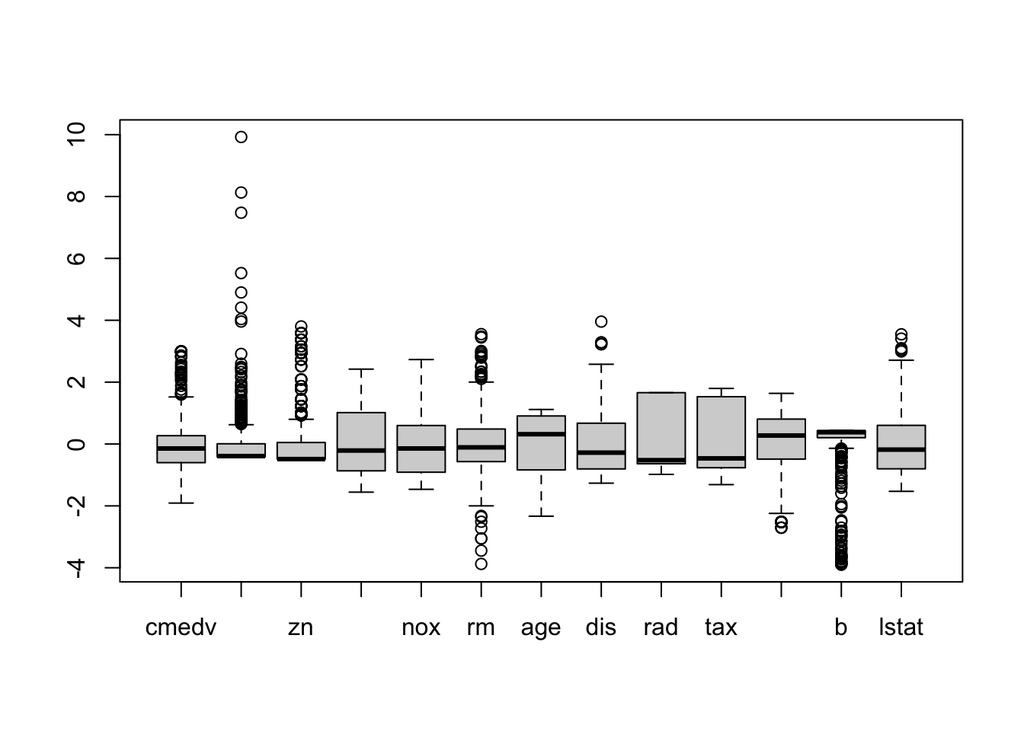

```r
pca=prcomp(BostonHousing2[,-c(1, 2, 3, 4, 5, 10)], scale=T)
new_data=scale(BostonHousing2[,-c(1, 2, 3, 4, 5, 10)])
boxplot(new_data)
```

```r
pca = prcomp(new_data, scale=TRUE)
su = summary(pca)

# calculate mean of variances explained by everything
mean(su$importance[2, ])
```

```
## [1] 0.07692385
```

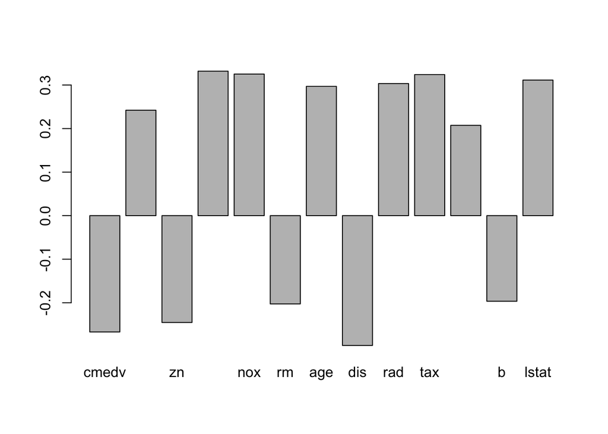

```r
# Keep all of the columns that have more than 7% (or whatever that mean val is above) of variance

barplot(pca$rotation[,1])
```

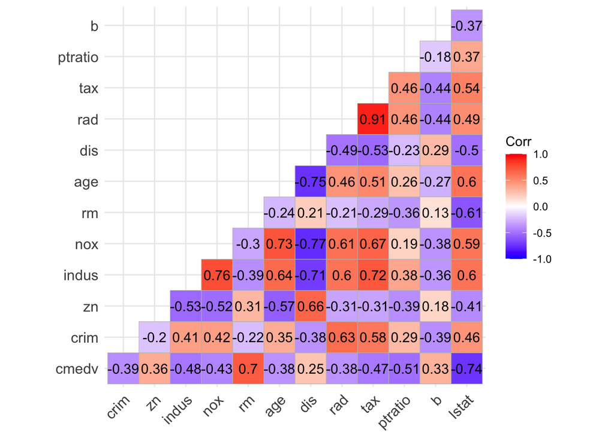

```r
ggcorrplot(cor(new_data),lab=T, type="lower")
```

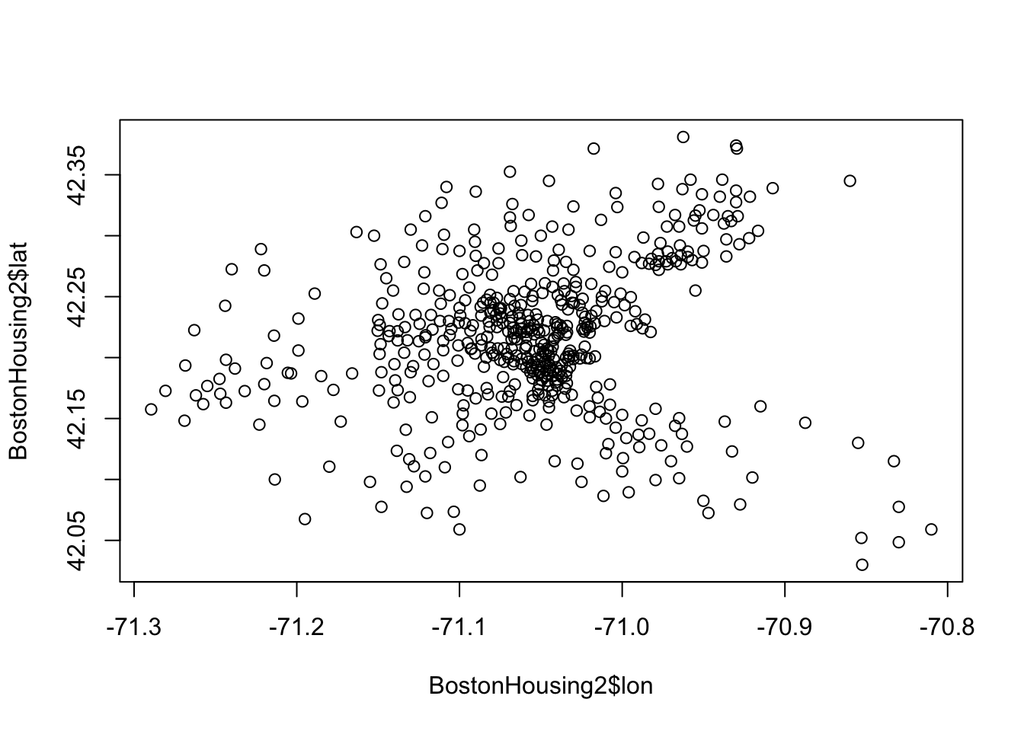

```r
plot(BostonHousing2$lon,BostonHousing2$lat)
```

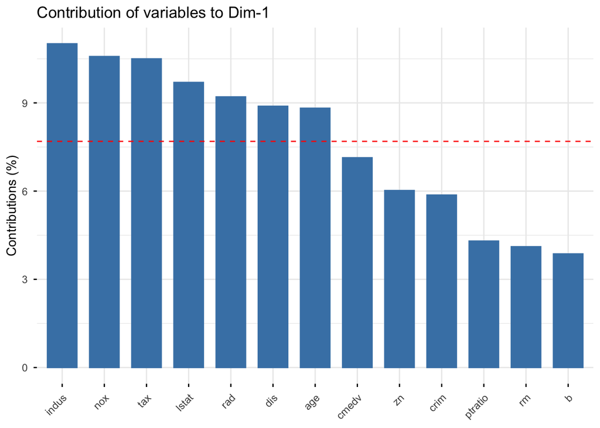

```r
# Function to determine
fviz_contrib(pca, choice="var", axes=1)
```

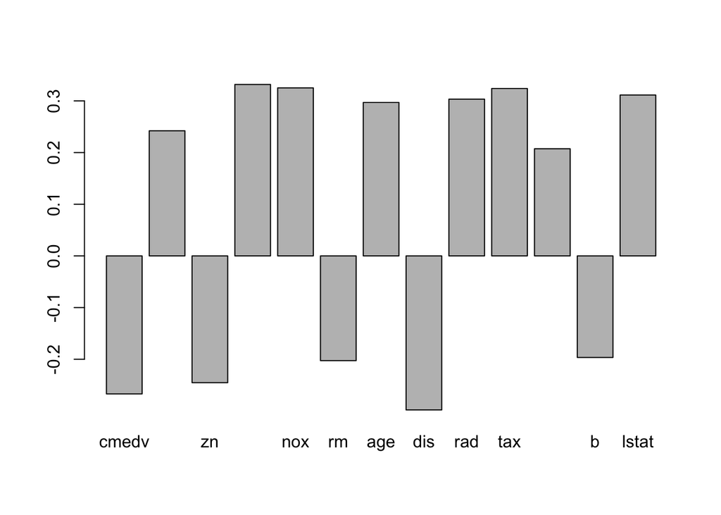

```r
barplot(pca$rotation[,1])
```

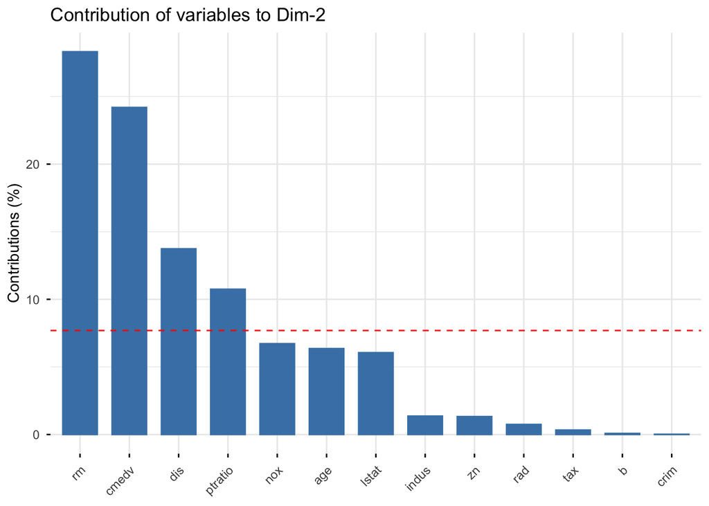

```r
fviz_contrib(pca, choice="var", axes=2)
```